# WaDE Dataset Cleaning

Cecilia Albert-Black

# Objective

The objective of this file is to clean the WaDE Synoptic Survey Dataset by removing missing values, flag (and sometimes filter out or replace) samples below detection limits.

We will only be applying these steps to variables which will be using to run BLM, which are

- Site Name
- Sample Name
- Temperature (C)
- pH
- Metal concentration (ug/L)
- Dissolved organic carbon concentration (DOC mg C/L)
- Humic acid (HA %)
- Calcium concentration (Ca mg/L)
- Magnesium concentration (Mg mg/L)
- Sodium concentration (Na mg/L)
- Potassium concentration (K mg/L)
- Sulfate concentration (SO4 mg/L)
- Chloride concentration (Cl mg/L)
- Alkalinity as dissolved inorganic carbon concentration (DIC mg/L)
- Sulfur concentration (S mg/L): under development, but must enter an arbitrary small quantity

At the end, we will have created the WaDE_Synoptic_Summary_Clean.xlsx file.

# 1. Import the WaDE Synoptic Survey Dataset

Import data from the tab called WaDE_SYNOPTIC_SUMMARY in the WaDE_Synoptic_Summary.xlsx file

```r
library(readxl)

WaDE_Synoptic_Summary <- read_excel("WaDE_Synoptic_Summary.xlsx",
                                    sheet = "WaDE_SYNOPTIC_SUMMARY")
```

Inspect the structure

```r
str(WaDE_Synoptic_Summary)
```

```
## tibble [629 × 133] (S3: tbl_df/tbl/data.frame)
##  $ Sample_ID     : chr [1:629] "WaDE_1" "WaDE_2" "WaDE_3" "WaDE_5" ...
##  $ Site          : chr [1:629] "BSL1.1" "BSL2.1" "BSL2.2" "BSL3.1" ...
##  $ Theme         : num [1:629] 1 1 1 1 1 1 1 1 1 1 ...
##  $ Regime        : chr [1:629] "Perennial" "Perennial" "Perennial" "Perennial" ...
##  $ Date          : POSIXct[1:629], format: "2023-04-12" "2023-04-12" ...
##  $ DateTime      : POSIXct[1:629], format: "2023-04-12 09:30:00" "2023-04-12 09:50:00" ...
##  $ Sampler       : chr [1:629] "Herndon" "Herndon" "Herndon" "Herndon" ...
##  $ Water_presence: chr [1:629] "Y" "Y" "Y" "Y" ...
##  $ Flow_state    : chr [1:629] "Flowing" "Flowing" "Flowing" "Flowing" ...
##  $ Depth         : num [1:629] -9999 -9999 -9999 -9999 -9999 ...
##  $ DO            : num [1:629] -9999 -9999 -9999 -9999 -9999 ...
##  $ DO_FLAG       : num [1:629] -1 -1 -1 -1 -1 -1 -1 -1 -1 -1 ...
##  $ DOsat         : num [1:629] -9999 -9999 -9999 -9999 -9999 ...
##  $ DOsat_FLAG    : num [1:629] -1 -1 -1 -1 -1 -1 -1 -1 -1 -1 ...
```

[output cut: 86 more lines]

Add units to variables according to the README tab

```r
library(dplyr)
WaDE_Synoptic_Summary <-
  WaDE_Synoptic_Summary %>%

  # 1) Keep only variables of interest
  dplyr::select(
    Sample_ID,
    Site,
    Date,
    Regime,
    Flow_state,
    Temp,
    pH,
    Zn,
    Cu,
    DOC,
    Ca,
    Mg,
    Na,
    K,
    SO4,
    Cl,
    DIC
  ) %>%

  # 2) Rename variables to include units
  rename(
    Temp_C = Temp,
    Zn_uM  = Zn,
    Cu_uM  = Cu,
    DOC_uM = DOC,
    Ca_uM  = Ca,
    Mg_uM  = Mg,
    Na_uM  = Na,
    K_uM   = K,
    SO4_uM = SO4,
    Cl_uM  = Cl,
    DIC_uM = DIC
  )

# Check
head(WaDE_Synoptic_Summary)
```

```
## # A tibble: 6 × 17
##   Sample_ID Site   Date                Regime    Flow_state Temp_C    pH  Zn_uM
##   <chr>     <chr>  <dttm>              <chr>     <chr>       <dbl> <dbl>  <dbl>
## 1 WaDE_1    BSL1.1 2023-04-12 00:00:00 Perennial Flowing      13.3  8.12 0.0561
## 2 WaDE_2    BSL2.1 2023-04-12 00:00:00 Perennial Flowing      13.9  7.82 0.064
## 3 WaDE_3    BSL2.2 2023-04-12 00:00:00 Perennial Flowing      14.5  7.78 0.0641
## 4 WaDE_5    BSL3.1 2023-04-12 00:00:00 Perennial Flowing      15.2  7.45 0.0537
## 5 WaDE_6    BSL3.3 2023-04-12 00:00:00 Perennial Flowing      15.2  7.35 0.0571
## 6 WaDE_7    BSL3.2 2023-04-12 00:00:00 Perennial Flowing      15.5  7.65 0.0322
## # ℹ 9 more variables: Cu_uM <dbl>, DOC_uM <dbl>, Ca_uM <dbl>, Mg_uM <dbl>,
## #   Na_uM <dbl>, K_uM <dbl>, SO4_uM <dbl>, Cl_uM <dbl>, DIC_uM <dbl>
```

Count the number of total observations in raw WaDE_Synoptic_Summary

```r
n_total <- length(unique(WaDE_Synoptic_Summary$Sample_ID))
n_total
```

```
## [1] 629
```

# 2. Omitting Samples with Missing Values

Samples will be omitted which do not have all BLM input variables.

Missing sample measurements are denoted with -9999 values.

```r
library(dplyr)

vars <- c(
  "Temp_C","Zn_uM","Cu_uM","DOC_uM","Ca_uM","Mg_uM",
  "Na_uM","K_uM","SO4_uM","Cl_uM","DIC_uM"
)

missing_dat <- WaDE_Synoptic_Summary %>%
  filter(if_any(all_of(vars), ~ .x == -9999)) %>%
  dplyr::select(Sample_ID, Site, Flow_state, all_of(vars))

missing_dat
```

```
## # A tibble: 243 × 14
##    Sample_ID Site   Flow_state Temp_C  Zn_uM   Cu_uM DOC_uM Ca_uM Mg_uM Na_uM
##    <chr>     <chr>  <chr>       <dbl>  <dbl>   <dbl>  <dbl> <dbl> <dbl> <dbl>
##  1 WaDE_1    BSL1.1 Flowing      13.3 0.0561 0.0049    71.7  1438   576   193
##  2 WaDE_2    BSL2.1 Flowing      13.9 0.064  0.00322   65    1290   613   195
##  3 WaDE_3    BSL2.2 Flowing      14.5 0.0641 0.00741  134.   2029   389   288
##  4 WaDE_5    BSL3.1 Flowing      15.2 0.0537 0.00235   41.7  1202   640   144
##  5 WaDE_6    BSL3.3 Flowing      15.2 0.0571 0.00275   34.2  1079   646   135
##  6 WaDE_7    BSL3.2 Flowing      15.5 0.0322 0.00291   53.3  1428   610   166
##  7 WaDE_8    BSL4.1 Pooled       12.7 0.0947 0.00844  168.   3036   734   541
##  8 WaDE_10   MCA3.3 Flowing      13.7 0.131  0.184     57.5   242   124   144
##  9 WaDE_11   MCA3.1 Flowing      15   0.0243 0.00184   63.3   664   360   128
## 10 WaDE_12   MCA2   Flowing      18.1 0.0289 0.00254   86.7   641   337    75
## # ℹ 233 more rows
## # ℹ 4 more variables: K_uM <dbl>, SO4_uM <dbl>, Cl_uM <dbl>, DIC_uM <dbl>
```

Summarize missing sample measurements

```r
# Number of affected samples
n_missing <- nrow(missing_dat)

# Variables most affected
variable_counts <- colSums(missing_dat[vars] == -9999, na.rm = TRUE)

n_missing # total numer of samples with at least 1 missing variable measurement
```

```
## [1] 243
```

```r
variable_counts # number of missing values by variable
```

```
## Temp_C  Zn_uM  Cu_uM DOC_uM  Ca_uM  Mg_uM  Na_uM   K_uM SO4_uM  Cl_uM DIC_uM
##    201    201    201    202    201    201    201    201    201    201    243
```

Determine why they´re missing

```r
# Dry events
dry_missing <- missing_dat[missing_dat$Flow_state == "Dry", ]
nrow(dry_missing)
```

```
## [1] 194
```

```r
# Flowing events
non_dry_missing <- missing_dat[missing_dat$Flow_state != "Dry", ]

nrow(non_dry_missing)
```

```
## [1] 49
```

```r
non_flowing_missing_counts <- colSums(non_dry_missing[vars] == -9999, na.rm = TRUE)
non_flowing_missing_counts
```

```
## Temp_C  Zn_uM  Cu_uM DOC_uM  Ca_uM  Mg_uM  Na_uM   K_uM SO4_uM  Cl_uM DIC_uM
##      7      7      7      8      7      7      7      7      7      7     49
```

Remove these from the WaDE_Synoptic_Summary and create a clean version of the dataset

```r
WaDE_Synoptic_Summary_Clean <- WaDE_Synoptic_Summary %>%
  filter(!if_any(all_of(vars), ~ .x == -9999))

# Count number of samples leftover
n_samples <- nrow(WaDE_Synoptic_Summary_Clean)
n_samples
```

```
## [1] 386
```

Build a summary table and export to Excel

```r
library(openxlsx)
# Dry events
dry_missing <- missing_dat[missing_dat$Flow_state == "Dry", ]
n_dry_missing <- nrow(dry_missing)

# Non-Dry events
non_dry_missing <- missing_dat[missing_dat$Flow_state != "Dry", ]
n_non_dry_missing <- nrow(non_dry_missing)
non_dry_missing_counts <- colSums(non_dry_missing[vars] == -9999, na.rm = TRUE)

# 1. Create a new Excel workbook
wb <- createWorkbook()

# 2. Add a worksheet called "Filtered Samples"
addWorksheet(wb, "Filtered Samples")

# 3. Make a small summary table of your counts
summary_table <- data.frame(
  Metric = c(
    "Total unique samples before filtering",
    "Samples with missing values of BLM vars",
    "Samples remaining after filtering",
    "Missing samples - Dry events",
    "Missing samples - Non-Dry events"
  ),
  Value = c(n_total, n_missing, n_samples, n_dry_missing, n_non_dry_missing)
)

# 4. Write the summary table at the top of the sheet (row 1)
writeData(
  wb,
  sheet = "Filtered Samples",
  x = summary_table,
  startRow = 1,
  startCol = 1
)


# 5. Write the full missing_dat table further down
start_row_missing_dat <- 1 + nrow(summary_table) + 3
writeData(
  wb,
  sheet = "Filtered Samples",
  x = missing_dat,
  startRow = start_row_missing_dat,
  startCol = 1
)

# 6. Save the workbook as an .xlsx file
saveWorkbook(wb, "Omitted_Samples.xlsx", overwrite = TRUE)
```

# 3. Handling Values Below Detection Limit

Values below detection limits (DL) were handled based on two scenarios:

1. **Field DL**: calculated as 3 standard deviations above field blank mean value, excluding outlier values
   - **If concentration > field DL**: flagged above detection limit (ADL) and retained as-is
   - **If 0 < concentrations < field DL**: flagged below detection limit (BDL) and retained as-is
   - **If concentration = 0**: flag as ZV and replaced by the lowest reported value of that element
   - **If concentration < 0**: flagged as negative (NV) and replaced by the lowest reported value of that element
2. **Instrument DL**: used for ions that did not have a field DL (i.e. Cl and SO4)
   - **If concentration > instrument DL**: flagged above detection limit (ADL) and retained as-is
   - **If 0 < concentration < instrument DL**: flag as BDL and left as-is
   - **If concentration = 0**: flag as ZV and replace with ½ the instrument DL
   - **If concentration < 0**: flagged as negative (NV) and replaced with ½ the instrument DL

The reasoning for omitting 0 and negative values is because

1. They are likely inaccurate
2. The BLM cannot handle 0 and negative values

### I. Zinc

Flag and replace the values according to scenario 1 and refer to the Detection Limits tab in WaDE_Synoptic_Summary.xlsx to obtain the field DL value

```r
library(dplyr)

# 1. Define the field detection limit for Zn in uM
Zn_DL_uM <- 6.69E-02

# 2. Find the lowest reported positive Zn_uM value
lowest_Zn_uM <- WaDE_Synoptic_Summary_Clean %>%
  filter(!is.na(Zn_uM), Zn_uM > 0) %>%
  summarise(min_Zn = min(Zn_uM)) %>%
  pull(min_Zn)

lowest_Zn_uM
```

```
## [1] 0.000627
```

```r
# 3. Apply detection-limit rules for Zn
WaDE_Synoptic_Summary_Clean <- WaDE_Synoptic_Summary_Clean %>%
  mutate(
    # Flag column for Zn based on your rules
    Zn_flag = case_when(
      Zn_uM < 0 ~ "NV",                       # negative values
      Zn_uM == 0 ~ "ZV",                      # zero values
      Zn_uM > 0 & Zn_uM < Zn_DL_uM ~ "BDL",   # 0 < conc < DL
      Zn_uM >= Zn_DL_uM ~ "ADL"               # ≥ DL = above detection limit
    ),

    # Overwrite Zn variable based on your replacement rules
    Zn_uM = case_when(
      Zn_uM < 0 ~ lowest_Zn_uM,           # NV → lowest reported positive Zn
      Zn_uM == 0 ~ lowest_Zn_uM,          # ZV → lowest reported positive Zn
      TRUE ~ Zn_uM                        # BDL and ADL retained as-is
    )
  )

# Inspect all assigned flags
table(WaDE_Synoptic_Summary_Clean$Zn_flag, useNA = "ifany")
```

```
##
## ADL BDL
## 265 121
```

Histogram of measured Zn (uM) with the field DL

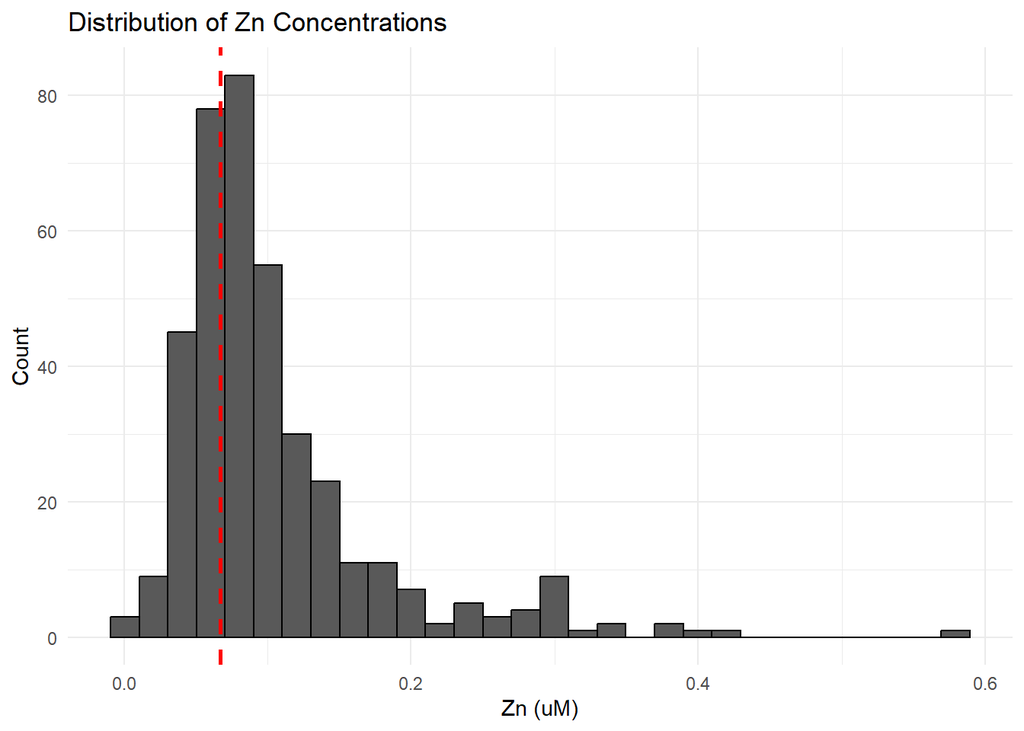

```r
library(ggplot2)

Zn_DL_uM <- 6.69E-02  # Detection limit

hist_zn <- ggplot(WaDE_Synoptic_Summary_Clean, aes(x = Zn_uM)) +
  geom_histogram(
    bins = 30,
    color = "black"
  ) +
  geom_vline(
    aes(xintercept = Zn_DL_uM),
    linetype = "dashed",
    linewidth = 1,
    color = "red"
  ) +
  labs(
    title = "Distribution of Zn Concentrations",
    x = "Zn (uM)",
    y = "Count"
  ) +
  theme_minimal()

hist_zn
```

### II. Copper

Flag and replace the values according to scenario 1 and refer to the Detection Limits tab in WaDE_Synoptic_Summary.xlsx to obtain the field DL value

```r
library(dplyr)

# 1. Define the field detection limit for Zn in uM
Cu_DL_uM <- 2.22E-03

# 2. Find the lowest reported positive Zn_uM value
lowest_Cu_uM <- WaDE_Synoptic_Summary_Clean %>%
  filter(!is.na(Cu_uM), Cu_uM > 0) %>%
  summarise(min_Cu = min(Cu_uM)) %>%
  pull(min_Cu)

lowest_Cu_uM
```

```
## [1] 0.000149
```

```r
# 3. Apply detection-limit rules for Zn
WaDE_Synoptic_Summary_Clean <- WaDE_Synoptic_Summary_Clean %>%
  mutate(
    # Flag column for Zn based on your rules
    Cu_flag = case_when(
      Cu_uM < 0 ~ "NV",                       # negative values
      Cu_uM == 0 ~ "ZV",                      # zero values
      Cu_uM > 0 & Cu_uM < Cu_DL_uM ~ "BDL",   # 0 < conc < DL
      Cu_uM >= Cu_DL_uM ~ "ADL"               # ≥ DL = above detection limit
    ),

    # Overwrite Zn variable based on your replacement rules
    Cu_uM = case_when(
      Cu_uM < 0 ~ lowest_Cu_uM,           # NV → lowest reported positive Zn
      Cu_uM == 0 ~ lowest_Cu_uM,          # ZV → lowest reported positive Zn
      TRUE ~ Cu_uM                        # BDL and ADL retained as-is
    )
  )

# Inspect all assigned flags
table(WaDE_Synoptic_Summary_Clean$Cu_flag, useNA = "ifany")
```

```
##
## ADL BDL  ZV
## 332  48   6
```

Histogram of measured Cu (uM) with the field DL

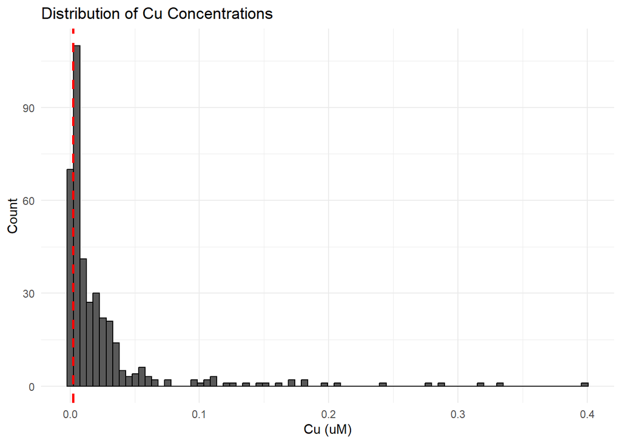

```r
hist_cu <- ggplot(WaDE_Synoptic_Summary_Clean, aes(x = Cu_uM)) +
  geom_histogram(
    bins = 80,
    color = "black"
  ) +
  geom_vline(
    aes(xintercept = Cu_DL_uM),
    linetype = "dashed",
    linewidth = 1,
    color = "red"
  ) +
  labs(
    title = "Distribution of Cu Concentrations",
    x = "Cu (uM)",
    y = "Count"
  ) +
  theme_minimal()

hist_cu
```

### III. Sulfate

Flag and replace the values according to scenario 2 and refer to the README tab in WaDE_Synoptic_Summary.xlsx for the instrument DL value.

```r
library(dplyr)

# 1. Define the instrument DL for sulfate in uM
SO4_DL_uM <- 1.7
SO4_half_DL_uM <- SO4_DL_uM / 2   # ½ the instrument DL

# 2. Find the lowest reported positive SO4_uM value
lowest_SO4_uM <- WaDE_Synoptic_Summary_Clean %>%
  filter(!is.na(SO4_uM), SO4_uM > 0) %>%
  summarise(min_SO4 = min(SO4_uM)) %>%
  pull(min_SO4)

lowest_SO4_uM
```

```
## [1] 7.5
```

```r
# 3. Apply detection-limit rules for sulfate
WaDE_Synoptic_Summary_Clean <- WaDE_Synoptic_Summary_Clean %>%
  mutate(
    # Flag column for sulfate
    SO4_flag = case_when(
      is.na(SO4_uM) ~ NA_character_,                # missing
      SO4_uM < 0 ~ "NV",                            # negative values (NV)
      SO4_uM == 0 ~ "ZV",                           # zero values (ZV)
      SO4_uM > 0 & SO4_uM < SO4_DL_uM ~ "BDL",      # 0 < conc < DL (BDL)
      SO4_uM >= SO4_DL_uM ~ "ADL"                   # ≥ DL = above detection limit
    ),

    # Adjusted sulfate values
    SO4_uM = case_when(
      SO4_uM < 0 ~ SO4_half_DL_uM,       # NV → replace with ½ instrument DL
      SO4_uM == 0 ~ SO4_half_DL_uM,      # ZV → replace with ½ instrument DL
      TRUE ~ SO4_uM                      # BDL and ADL retained as-is
    )
  )

# Inspect
table(WaDE_Synoptic_Summary_Clean$SO4_flag, useNA = "ifany")
```

```
##
## ADL  ZV
## 384   2
```

Histogram with instrument DL

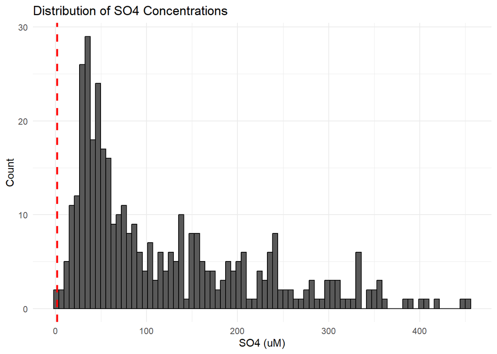

```r
hist_so4 <- ggplot(WaDE_Synoptic_Summary_Clean, aes(x = SO4_uM)) +
  geom_histogram(
    bins = 80,
    color = "black"
  ) +
  geom_vline(
    aes(xintercept = SO4_DL_uM),
    linetype = "dashed",
    linewidth = 1,
    color = "red"
  ) +
  labs(
    title = "Distribution of SO4 Concentrations",
    x = "SO4 (uM)",
    y = "Count"
  ) +
  theme_minimal()

hist_so4
```

### IV. Chloride

Instrument DL: 22.9 uM

```r
# 1. Define the instrument detection limit for chloride in uM
Cl_DL_uM <- 2.29e1              # instrument DL = 22.9 uM
Cl_half_DL_uM <- Cl_DL_uM / 2   # ½ the instrument DL

# 2. Find the lowest reported positive Cl_uM value
lowest_Cl_uM <- WaDE_Synoptic_Summary_Clean %>%
  filter(!is.na(Cl_uM), Cl_uM > 0) %>%
  summarise(min_Cl = min(Cl_uM)) %>%
  pull(min_Cl)

lowest_Cl_uM
```

```
## [1] 16
```

```r
# 3. Apply detection-limit rules for chloride
WaDE_Synoptic_Summary_Clean <- WaDE_Synoptic_Summary_Clean %>%
  mutate(
    # Flag column for chloride
    Cl_flag = case_when(
      Cl_uM < 0 ~ "NV",                           # negative values → NV
      Cl_uM == 0 ~ "ZV",                          # zero values → ZV
      Cl_uM > 0 & Cl_uM < Cl_DL_uM ~ "BDL",       # 0 < conc < DL → BDL
      Cl_uM >= Cl_DL_uM ~ "ADL"                   # ≥ DL = above detection limit
    ),

    # Adjusted chloride values
    Cl_uM = case_when(
      Cl_uM < 0 ~ Cl_half_DL_uM,        # NV → replace with ½ instrument DL
      Cl_uM == 0 ~ Cl_half_DL_uM,       # ZV → replace with ½ instrument DL
      TRUE ~ Cl_uM                      # BDL and ADL retained as-is
    )
  )

# Inspect
table(WaDE_Synoptic_Summary_Clean$Cl_flag, useNA = "ifany")
```

```
##
## ADL BDL  ZV
## 377   4   5
```

Histogram with instrument DL

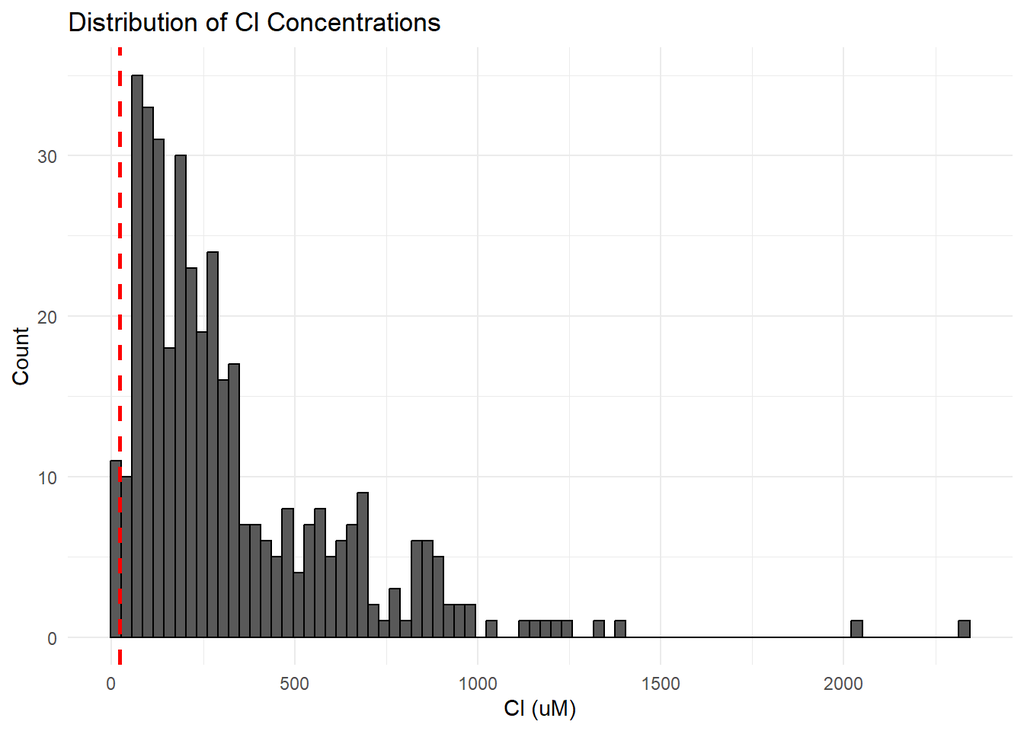

```r
hist_cl <- ggplot(WaDE_Synoptic_Summary_Clean, aes(x = Cl_uM)) +
  geom_histogram(
    bins = 80,
    color = "black"
  ) +
  geom_vline(
    aes(xintercept = Cl_DL_uM),
    linetype = "dashed",
    linewidth = 1,
    color = "red"
  ) +
  labs(
    title = "Distribution of Cl Concentrations",
    x = "Cl (uM)",
    y = "Count"
  ) +
  theme_minimal()

hist_cl
```

# 4. Export Clean Dataset

Create a clean WaDE Synoptic Survey Dataset

```r
library(writexl)

# Zinc
write_xlsx(WaDE_Synoptic_Summary_Clean, "WaDE_Synoptic_Summary_Clean.xlsx")
```